# 9_Find_Mistakes

Reesa John

February 20, 2019

# Introduction

Today you will learn about **linear models*, by studying the popularity of names over time.

Unfortunately, there are many errors in this markdown file! As you work through the activity, correct the mistakes, so that your final version is a beautiful knitted markdown report.

# The Data

Our dataset in this lab concerns baby names and their popularity over time. The dataset “babies_ca.xlsx” has information about baby names in California from 1940-2016. For each year, and for each name with at least 50 recorded babies born, we are given the counts of how many babies had that name.

For now, we will study only the name “Kelly”. First we read in that data:

```r
library(tidyverse)
```

```r
#fixed kellys and the include = FALSE, and renamed {r plots}, fixed data in lm and switched y and x, kellys_89 didn't edit itselffor ggplot, mutate residuals
kellys = read_delim("./Babyname_Datasets/kellys_ca.txt",delim =" ")
```

# Trend in Kellys over time

Let’s take a look at how the name “Kelly” has changed over time. The following code will plot the counts for each year.

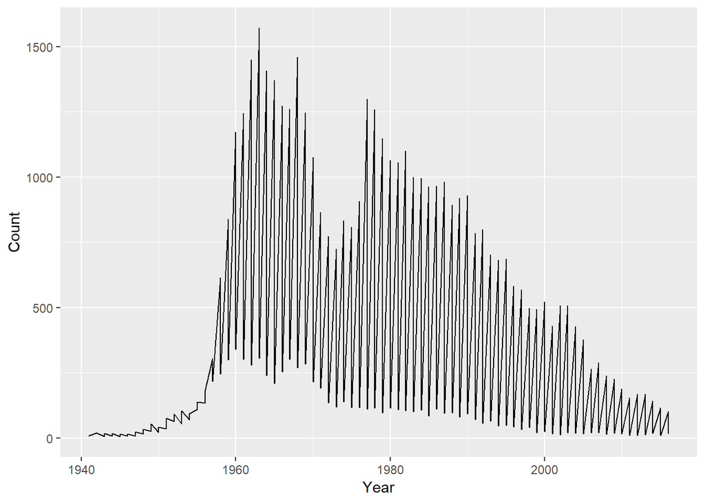

```r
ggplot(kellys, aes(x = Year, y = Count)) + geom_line()
```

Hmmm, interesting. There seems to be a spike at 1957. I wonder why that is.

My favorite hockey player growing up was named Kelly Hrudey. I thought it was cool that we had the same name. These days, you don’t see many male Kelly’s. Lets track gender as well in our plot

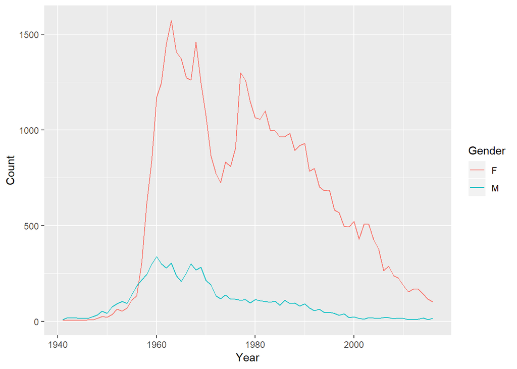

```r
ggplot(kellys, aes(x = Year, y = Count, color = Gender)) + geom_line()
```

Why did the name Kelly suddenly get popular as a girl’s name around 1957? Why did it spike again around 1978? I don’t know the answers and I am genuinely curious - students have found some interesting theories over the years!

# Is my name not cool any more?

I was born in 1989. Let’s look at only the time frame since I was named.

```r
kellys_89 <- kellys %>%
  filter(Year >= 1989)
```

We will create a linear model with the year as the explanatory variable, and the number of Kellys as the response.

[output not shown]

It does seem that the name Kelly has decreased in popularity over time. Bummer.

Let’s plot this linear model.

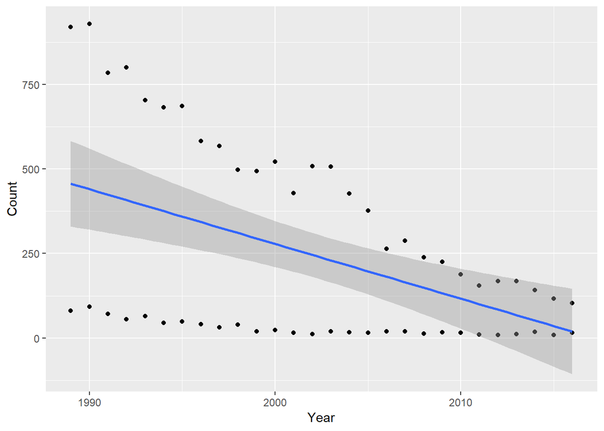

```r
ggplot(kellys_89, aes(x = Year, y = Count)) +
  geom_point() +
  stat_smooth(method = "lm")
```

We should also check out the *residuals*. Although there are some automatic ways to do this, we’ll do it by hand for practice.

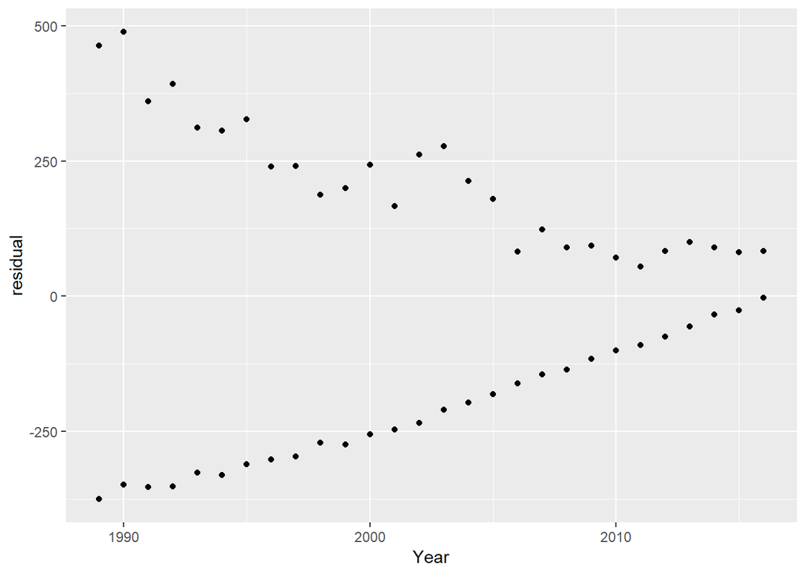

```r
library(modelr)
## Hint: Look at the documentation for add_predictions

kellys_89 <- kellys_89 %>%
  add_predictions(my_model) %>%
  mutate(residual = Count - pred)

ggplot(kellys_89, aes(x = Year, y = residual))+geom_point()
```

What about by gender?

```r
my_model_2 <- lm(Count ~ Year*Gender, data = kellys_89)

summary(my_model_2)
```

```
##
## Call:
## lm(formula = Count ~ Year * Gender, data = kellys_89)
##
## Residuals:
##     Min      1Q  Median      3Q     Max
## -82.389 -18.445   0.045  15.394 108.871
##
## Coefficients:
##                Estimate Std. Error t value Pr(>|t|)
## (Intercept)   6.046e+04  1.738e+03   34.78   <2e-16 ***
## Year         -2.997e+01  8.681e-01  -34.52   <2e-16 ***
## GenderM      -5.558e+04  2.458e+03  -22.61   <2e-16 ***
## Year:GenderM  2.755e+01  1.228e+00   22.44   <2e-16 ***
## ---
## Signif. codes:  0 '***' 0.001 '**' 0.01 '*' 0.05 '.' 0.1 ' ' 1
##
## Residual standard error: 37.1 on 52 degrees of freedom
## Multiple R-squared:  0.9827, Adjusted R-squared:  0.9817
## F-statistic: 983.6 on 3 and 52 DF,  p-value: < 2.2e-16
```

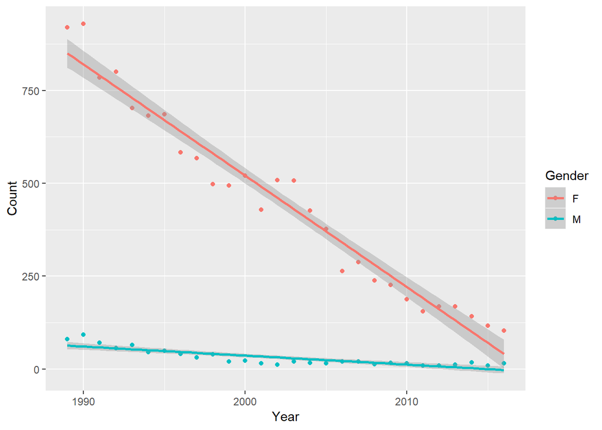

```r
ggplot(kellys_89, aes(x = Year, y = Count, color = Gender)) + geom_point() + stat_smooth(method = "lm")
```

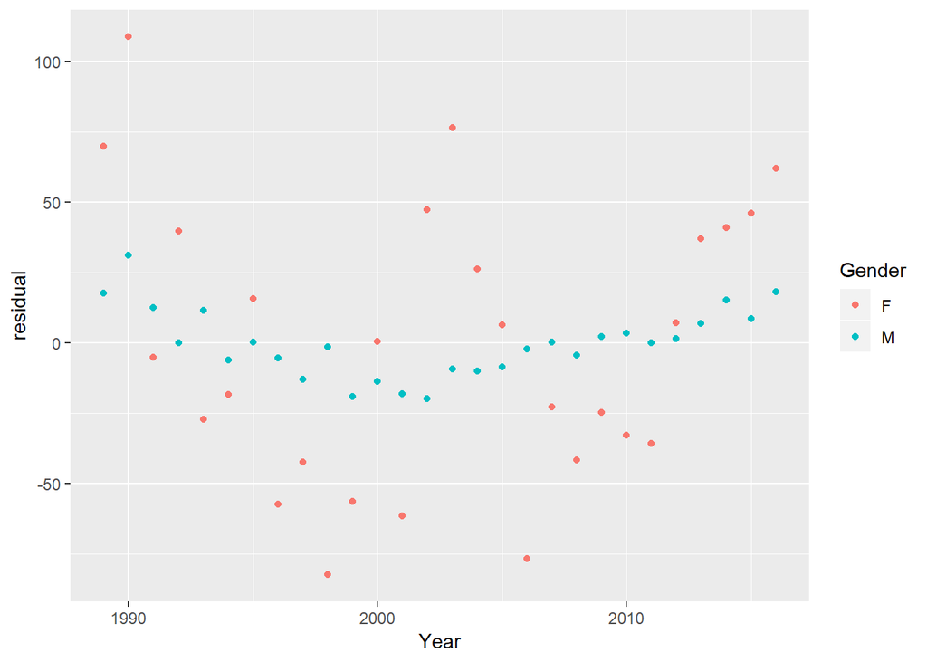

```r
kellys_89 <- kellys_89 %>%
  add_predictions(my_model_2) %>%
  mutate(
    residual = Count - pred
  )

ggplot(kellys_89, aes(x = Year, y = residual, color = Gender)) + geom_point()
```